# Spatial Lattice Data

Yang Li

2026-05-22

# Spatial Lattice Data

**Spatial lattice data** arise when observations are associated with discrete spatial units, such as counties, census tracts, neighborhoods, pixels, or grid cells.

Unlike geostatistics data, where measurements are taken at exact coordinates, lattice data are indexed by regions or cells, and spatial dependence is usually defined through neighborhood relationships, such as whether two regions share a border.

The basic idea is still that nearby regions may have similar values.

Spatial lattice data are important because many public health, environmental, and social science datasets are collected over administrative regions rather than exact point locations.

Examples include:

- disease incidence rates by county,
- cancer mortality rates by state,
- air pollution levels on a regular grid,
- poverty rates by census tract,
- crop yields by agricultural field plots.

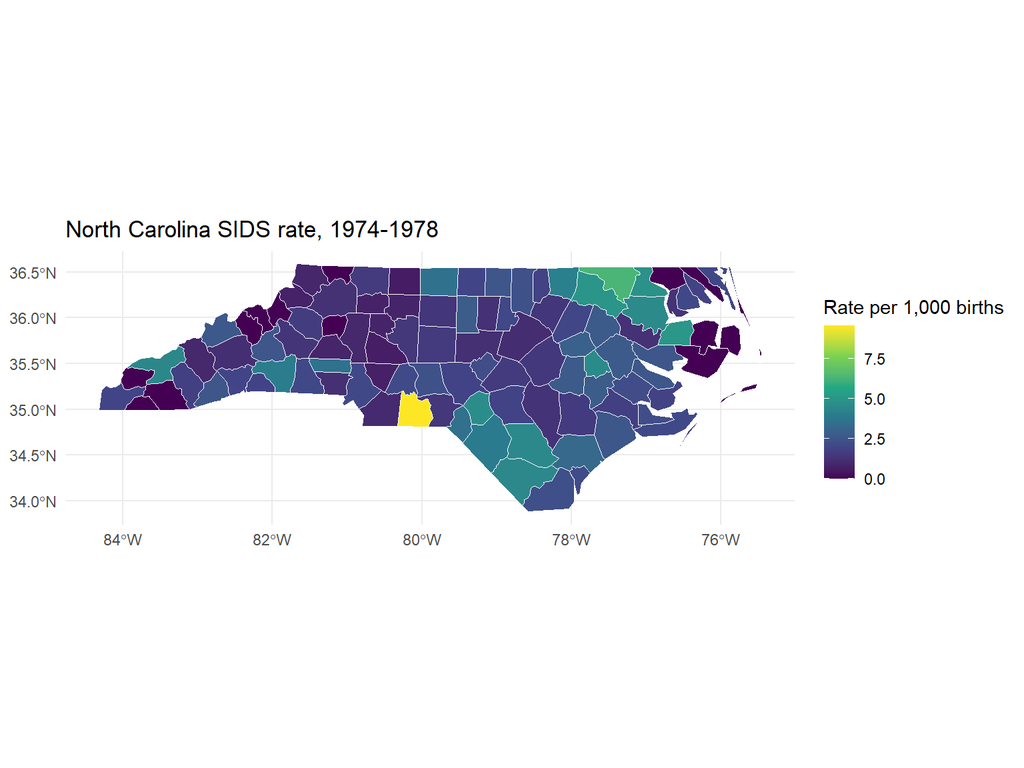

# Spatial weight matrix $W$

$W$ is the spatial weight matrix with values

$$w_{ij}=\begin{cases}1, & \text{if region $i$ and $j$ are
neighbors}\\
0, & \text{if region $i$ and $j$ are not neighbors}
\end{cases}$$

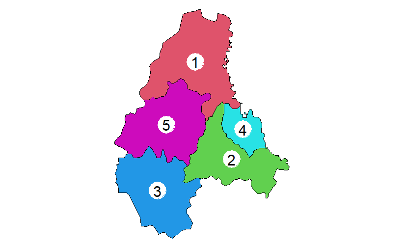

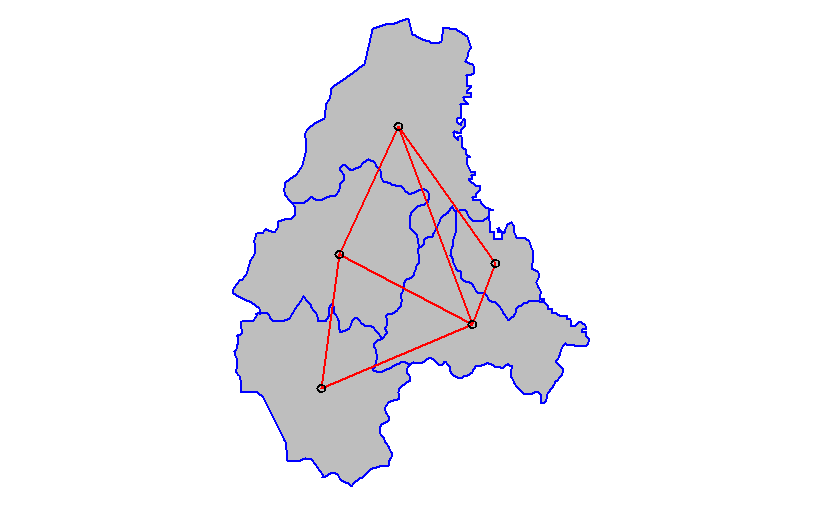

$$W=\begin{array}{c c}
&
\begin{array}{ccccc}
1 & 2 & 3 & 4 & 5
\end{array}
\\
\begin{array}{c}
1 \\ 2 \\ 3 \\ 4 \\ 5
\end{array}
&
\left(
\begin{array}{ccccc}
0 & 1 & 0 & 1 & 1\\
1 & 0 & 1 & 1 & 1\\
0 & 1 & 0 & 0 & 1\\
1 & 1 & 0 & 0 & 0\\
1 & 1 & 1 & 0 & 0
\end{array}
\right)
\end{array}$$

# Measurement of Spatial Autocorrelation

- Moran’s I

$$I=\frac{n\sum_{i=1}^{n}\sum_{j=1}^{n}w_{ij}(y_i-\bar{y})(y_j-\bar{y})}{S_0
\sum_{i=1}^{n}(y_i-\bar{y})^2}$$

where $w_{ij}$ are the spatial weights, $S_0=\sum_{i=1}^{n}\sum_{j=1}^{n}w_{ij}$

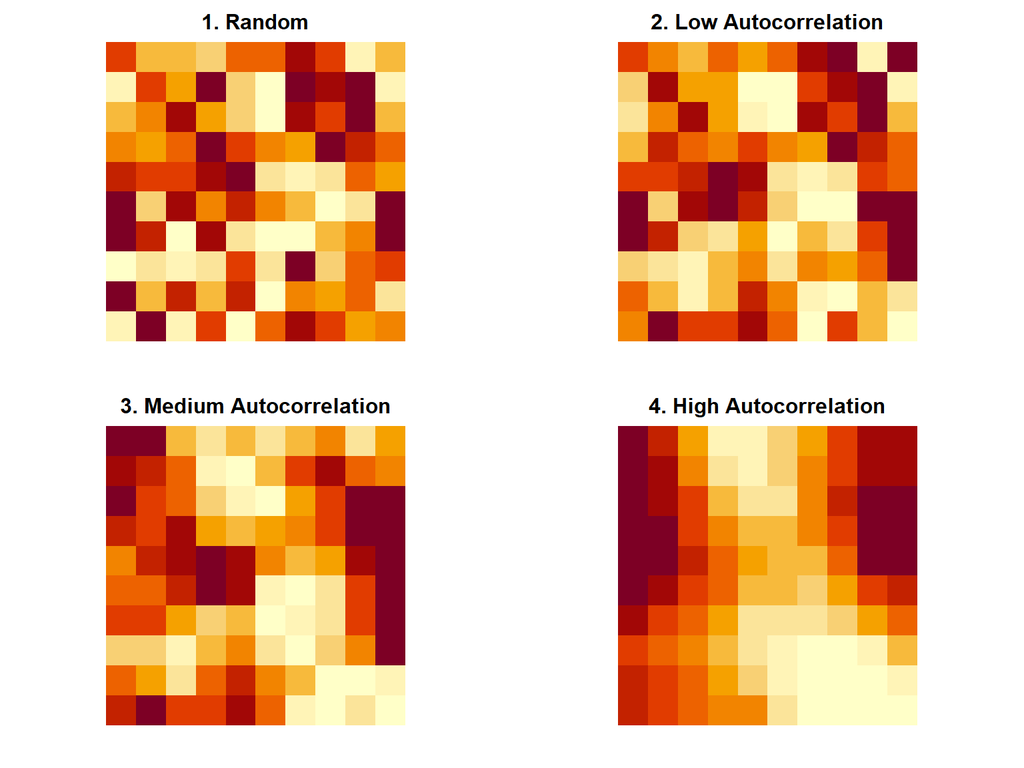

Moran’s I value:

- Random: 0.0179
- Low autocorrelation: 0.475
- Medium autocorrelation: 0.649
- High autocorrelation: 0.892

# Test Moran’s I

- **Why**: Are similar values more likely to occur near each other than would be expected by chance?
- **What**: Moran’s I tells us whether high values are near high values and low near low, more than expected under spatial randomness.
- **How**: Permutation test
  - Randomly shuffle the observed values across locations
  - Recompute Moran’s I each time
  - This breaks any spatial structure while preserving the data values

$$E[I] = \frac{-1}{n-1}$$

$$Var[I] = \frac{n^2(n-1)S_1 - n(n-1)S_2 - 2 S_0^2}{(n+1)(n-1)^2 S_0^2},$$
$$S_0 = \sum_{i \neq j} w_{ij},\ S_1= \frac{1}{2}\sum_{i\neq j}
(w_{ij}+w_{ji})^2\mbox{ and } S_2 = \sum_k \left(\sum_j w_{kj}+\sum_i
w_{ik}\right)^2.$$

# Moran’s Test in R

## Generate Data

```r
library(spdep)
```

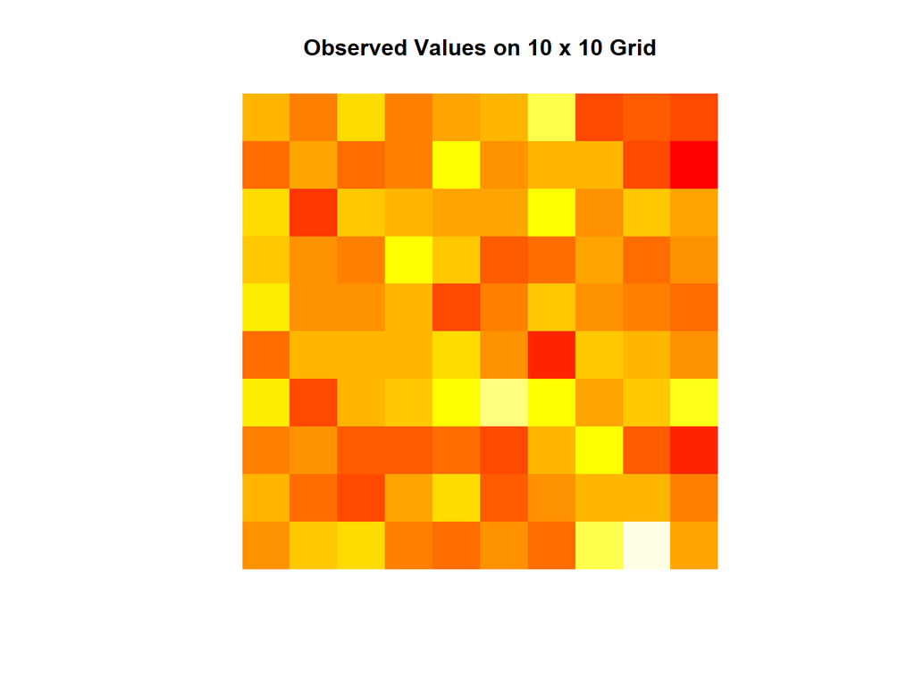

```r
z <- rnorm(100)
zmat <- matrix(z, nrow = 10, ncol = 10, byrow = TRUE)
image(t(zmat[10:1, ]),   # flip so row 1 appears at the top
    col = heat.colors(20),
    main = "Observed Values on 10 x 10 Grid",
    asp=1,
    axes=FALSE
)
```

## Spatial Weight Matrix

```r
# Create a 10 by 10 lattice neighbor structure
nb <- cell2nb(
    nrow = 10,
    ncol = 10,
    type = "rook"
)

# Convert neighbors to spatial weights
lw <- nb2listw(nb, style = "W")

# Convert to matrix form
W <- listw2mat(lw)
```

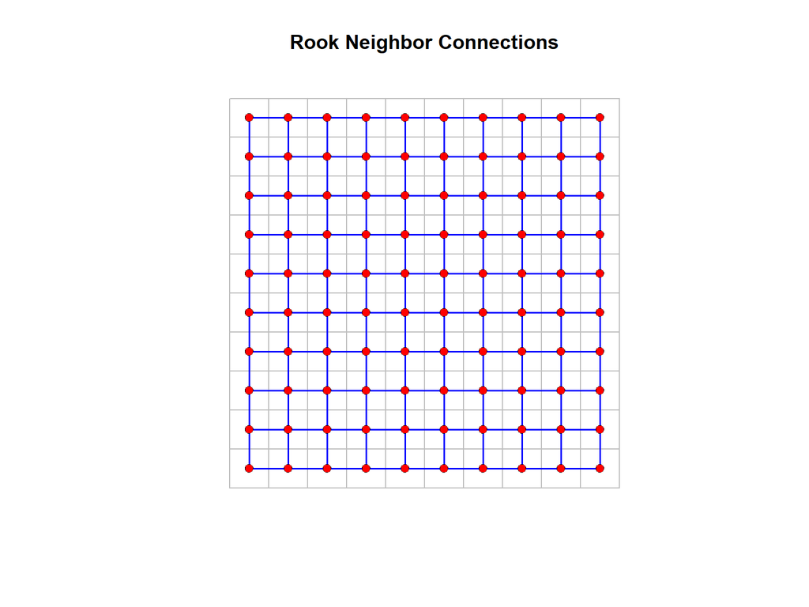

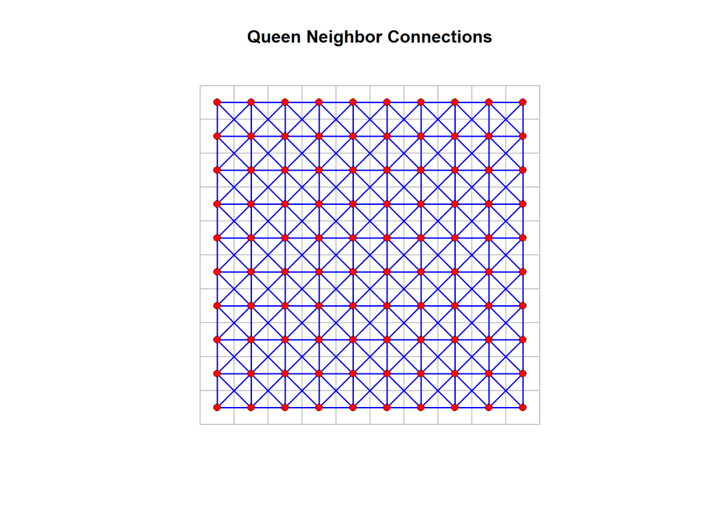

## Compute Moran’s I

```r
moran_I <- function(z, W) {
    n <- length(z)
    z_centered <- z - mean(z)
    S0 <- sum(W)

    I <- (n / S0) *
        as.numeric(t(z_centered) %*% W %*% z_centered) /
        sum(z_centered^2)

    return(I)
}

observed_I <- moran_I(z, W)
observed_I
```

```
## [1] 0.05543753
```

## Permutation Test (Manual)

```r
B <- 1000
perm_I <- numeric(B)

for (b in 1:B) {
    z_perm <- sample(z)
    perm_I[b] <- moran_I(z_perm, W)
}

p_value <- (sum(perm_I >= observed_I) + 1) / (B + 1)
p_value
```

```
## [1] 0.1938062
```

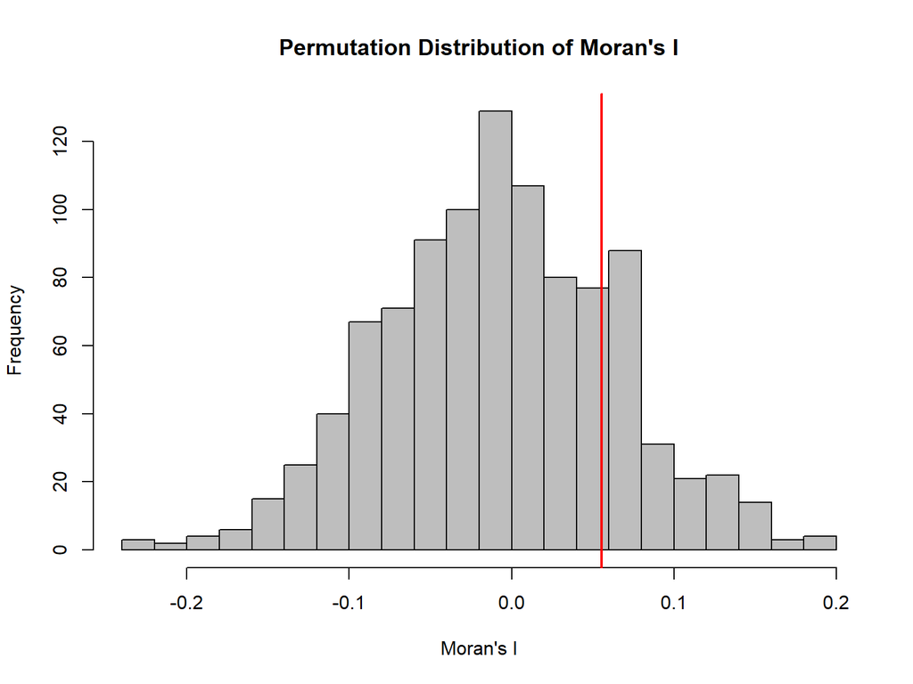

```r
hist(perm_I,
    breaks = 30,
    main = "Permutation Distribution of Moran's I",
    xlab = "Moran's I",
    col = "gray"
)

abline(v = observed_I, col = "red", lwd = 2)
```

## Test using Package

```r
library(spdep)

# Suppose z is your observed data vector of length 100
# z <- your_values

# Create neighbors for a 10 by 10 grid
nb <- cell2nb(
  nrow = 10,
  ncol = 10,
  type = "rook"
)

# Convert neighbors to spatial weights
lw <- nb2listw(nb, style = "W")

moran.test(z, lw)
```

```
##
##  Moran I test under randomisation
##
## data:  z
## weights: lw
##
## Moran I statistic standard deviate = 0.88696, p-value = 0.1876
## alternative hypothesis: greater
## sample estimates:
## Moran I statistic       Expectation          Variance
##       0.055437526      -0.010101010       0.005459968
```

`moran.test()` computes Moran’s I using a theoretical approximation for the null distribution.

```r
set.seed(123)

moran_perm <- moran.mc(
  z,
  listw = lw,
  nsim = 1000,
  alternative = "greater"
)

moran_perm
```

```
##
##  Monte-Carlo simulation of Moran I
##
## data:  z
## weights: lw
## number of simulations + 1: 1001
##
## statistic = 0.055438, observed rank = 803, p-value = 0.1978
## alternative hypothesis: greater
```

`moran.mc()` repeatedly shuffles the observed values across the fixed spatial locations. For each shuffle, it recalculates Moran’s I. Then it compares the observed Moran’s I with this simulated permutation distribution.